# Introduction to Machine Learning in the Digital Humanities - Day 2

# Today’s class

- Scraping Twitter
- Sentiment Analysis
- Supervised Machine Learning
- tf-idf
- n grams

# Sentiment Analysis

Are these tweets related to #ParisClimateDeal positive or negative?

## tweet 1

[figure not shown]

## tweet 2

[figure not shown]

Below is a basic sentiment analysis using tidytext.

```r
bing_lex <- get_sentiments("bing")

tweet1 <- data_frame(text = c("Pulling out of the #ParisClimateDeal is reckless and regressive. Instead of handholding, I'll work for a sustainable future for our planet."))

fn_sentiment <- tweet1 %>% unnest_tokens(word,text) %>%  left_join(bing_lex)

fn_sentiment %>% filter(!is.na(sentiment)) %>% group_by(sentiment) %>% summarise(n=n())

afinn_lex <- get_sentiments("afinn")

fn_sentiment <- tweet1 %>% unnest_tokens(word,text) %>%  left_join(afinn_lex)

fn_sentiment %>% filter(!is.na(score)) %>% summarise(mean=mean(score))

sentiment(tweet1)
mean(sentiment(tweet1)$sentiment)

tweet2 <- data_frame(text=c("The USA is not an ulimited bank account for rich countries pretending to be poor. Pay your fair share for #NATO and the #ParisClimateDeal."))

fn_sentiment <- tweet2 %>% unnest_tokens(word,text) %>%  left_join(bing_lex)

fn_sentiment %>% filter(!is.na(sentiment)) %>% group_by(sentiment) %>% summarise(n=n())

fn_sentiment <- tweet1 %>% unnest_tokens(word,text) %>%  left_join(afinn_lex)

fn_sentiment %>% filter(!is.na(score)) %>% summarise(mean=mean(score))

sentiment(tweet2)
mean(sentiment(tweet2)$sentiment)

#make interactive with class by asking for text
# ask class to give text a score

text <- c("she is a dog that plays with children then hates lovely kids because bob dylan; is a goat that drives a bike and sings classical trumpet")
```

[output not shown]

# What is Sentiment analysis?

- Often called opinion mining.

> When we read text we use our understanding of the emotional intent to infer whether a section of text is positive or negative, or perhaps characterized by some other more nuanced emotion like surprise or disgust.

> We can use the tools of text mining to approach the emotional content of text programmatically,

> One way to analyze the sentiment of a text is to consider the text as a combination of its individual words and the sentiment content of the whole text as the sum of the sentiment content of the individual words. This isn’t the only way to approach sentiment analysis, but it is an often-used approach, and an approach that naturally takes advantage of the tidy tool ecosystem.

(Silage and Robinson, 2017)

# The `sentiments` dataset in `tidytext`

```r
sentiments
```

```
## # A tibble: 27,314 x 4
##    word        sentiment lexicon score
##    <chr>       <chr>     <chr>   <int>
##  1 abacus      trust     nrc        NA
##  2 abandon     fear      nrc        NA
##  3 abandon     negative  nrc        NA
##  4 abandon     sadness   nrc        NA
##  5 abandoned   anger     nrc        NA
##  6 abandoned   fear      nrc        NA
##  7 abandoned   negative  nrc        NA
##  8 abandoned   sadness   nrc        NA
##  9 abandonment anger     nrc        NA
## 10 abandonment fear      nrc        NA
## # ... with 27,304 more rows
```

- There are three general sentiment lexicons in the `sentiments` dataset.
> - `AFINN` from [Finn Årup Nielsen](http://www2.imm.dtu.dk/pubdb/views/publication_details.php?id=6010),
> - `bing` from [Bing Liu and collaborators](https://www.cs.uic.edu/~liub/FBS/sentiment-analysis.html), and
> - `nrc` from [Saif Mohammad and Peter Turney](http://saifmohammad.com/WebPages/NRC-Emotion-Lexicon.htm).

Comments:

- All three are based on single words (i.e., unigrams).
- `nrc` has sentiment categories (positive, negative), and emotional categories (anger, anticipation, disgust, fear, joy, sadness, surprise, trust).

```r
get_sentiments("nrc")
```

```
## # A tibble: 13,901 x 2
##    word        sentiment
##    <chr>       <chr>
##  1 abacus      trust
##  2 abandon     fear
##  3 abandon     negative
##  4 abandon     sadness
##  5 abandoned   anger
##  6 abandoned   fear
##  7 abandoned   negative
##  8 abandoned   sadness
##  9 abandonment anger
## 10 abandonment fear
## # ... with 13,891 more rows
```

- `bing` has sentiment categories (positive, negative).

```r
get_sentiments("bing")
```

```
## # A tibble: 6,788 x 2
##    word        sentiment
##    <chr>       <chr>
##  1 2-faced     negative
##  2 2-faces     negative
##  3 a+          positive
##  4 abnormal    negative
##  5 abolish     negative
##  6 abominable  negative
##  7 abominably  negative
##  8 abominate   negative
##  9 abomination negative
## 10 abort       negative
## # ... with 6,778 more rows
```

- `AFINN` assigns a score from -5 (negative sentiment) to +5 (positive sentiment).

```r
get_sentiments("afinn")
```

```
## # A tibble: 2,476 x 2
##    word       score
##    <chr>      <int>
##  1 abandon       -2
##  2 abandoned     -2
##  3 abandons      -2
##  4 abducted      -2
##  5 abduction     -2
##  6 abductions    -2
##  7 abhor         -3
##  8 abhorred      -3
##  9 abhorrent     -3
## 10 abhors        -3
## # ... with 2,466 more rows
```

> How were these sentiment lexicons put together and validated? They were constructed via either crowdsourcing (using, for example, Amazon Mechanical Turk) or by the labor of one of the authors, and were validated using some combination of crowdsourcing again, restaurant or movie reviews, or Twitter data. Given this information, we may hesitate to apply these sentiment lexicons to styles of text dramatically different from what they were validated on, such as narrative fiction from 200 years ago. While it is true that using these sentiment lexicons with, for example, Jane Austen’s novels may give us less accurate results than with tweets sent by a contemporary writer, we still can measure the sentiment content for words that are shared across the lexicon and the text. (Silage and Robinson, 2017)

> Dictionary-based methods like the ones we are discussing find the total sentiment of a piece of text by adding up the individual sentiment scores for each word in the text. (Silage and Robinson, 2017)

> Not every English word is in the lexicons because many English words are pretty neutral. It is important to keep in mind that these methods do not take into account qualifiers before a word, such as in “no good” or “not true”; a lexicon-based method like this is based on unigrams only. (Silage and Robinson, 2017)

# Sentiment analysis of Yelp reviews

This material is based on a blog post by [David Robinson](http://varianceexplained.org/r/yelp-sentiment/).

- Does sentiment analysis work?
- Can you predict positivity or negativity by assigning sentiment scores to words?

# The Yelp Dataset

[figure not shown]

The dataset is from the [Yelp dataset challenge](https://www.yelp.com/dataset_challenge)

```r
reviews <- read_csv("~/Dropbox/Docs/DHSI/DHSI-2017/day2/yelp.csv")

review_words <- reviews %>% dplyr::select(review_id,stars,text)  %>% unnest_tokens(word,text) %>% filter(!word %in% stop_words$word, str_detect(word, "^[a-z']+$"))

head(reviews)
```

```
## # A tibble: 6 x 10
##   review_id  user_id business_id stars date       text  useful funny  cool
##   <chr>      <chr>   <chr>       <int> <date>     <chr>  <int> <int> <int>
## 1 NxL8SIC5y… KpkOkG… 2aFiy99vNL…     5 2011-10-10 If y…      0     0     0
## 2 pXbbIgOXv… bQ7fQq… 2aFiy99vNL…     5 2010-12-29 "Aft…      1     0     0
## 3 wslW2Lu4N… r1NUhd… 2aFiy99vNL…     5 2011-04-29 Grea…      0     0     0
## 4 GP6YEearU… aW3ix1… 2LfIuF3_sX…     5 2014-07-14 High…      0     0     1
## 5 25RlYGq2s… YOo-Ci… 2LfIuF3_sX…     4 2014-01-15 I wa…      0     0     0
## 6 Uf1Ki1yyH… bgl3j8… 2LfIuF3_sX…     5 2013-04-28 What…      2     0     1
## # ... with 1 more variable: type <chr>
```

```r
head(review_words)
```

```
## # A tibble: 6 x 3
##   review_id              stars word
##   <chr>                  <int> <chr>
## 1 NxL8SIC5yqOdnlXCg18IBg     5 enjoy
## 2 NxL8SIC5yqOdnlXCg18IBg     5 service
## 3 NxL8SIC5yqOdnlXCg18IBg     5 competent
## 4 NxL8SIC5yqOdnlXCg18IBg     5 personable
## 5 NxL8SIC5yqOdnlXCg18IBg     5 recommend
## 6 NxL8SIC5yqOdnlXCg18IBg     5 corey
```

# Is text sentiment associated with star rating?

Is there a relationship between star rating and sentiment?

Use AFINN lexicon and do an inner-join operation.

```r
AFINN <- sentiments %>%
  filter(lexicon == "AFINN") %>%
  dplyr::select(word, afinn_score = score)

reviews_sentiment <- review_words %>%
  inner_join(AFINN, by = "word") %>%
  group_by(review_id, stars) %>%
  summarize(sentiment = mean(afinn_score))

reviews_sentiment
```

```
## # A tibble: 944 x 3
## # Groups:   review_id [?]
##    review_id              stars sentiment
##    <chr>                  <int>     <dbl>
##  1 _-L6PugX8QuW8BH9d20jpA     1    -4
##  2 _0FegzOEqrJupsYu408c8Q     4     1.5
##  3 _6i3yW-Tg5Lua-zFLAsrWA     4     2.33
##  4 _a7Zu2ZSEGO4bl2gvu7OtQ     5     2.67
##  5 _B49HDJ8DirgEegyslLbdA     5     2.33
##  6 _dT_bL0WG6Mc3KsLrhBToQ     5     2.57
##  7 _FgnB8tG-oKwtx96qR1ljQ     4     0.333
##  8 _fKKTE17IGF3rTbs3HEGmw     3     1.5
##  9 _gyfKZW4056rjnEoR99mmQ     2     1.2
## 10 _KBLQufhg4_OP0V_q8ZKqA     5     1
## # ... with 934 more rows
```

Now we have an average sentiment for each review with a star rating.

This is an example of side-by-side boxplots.

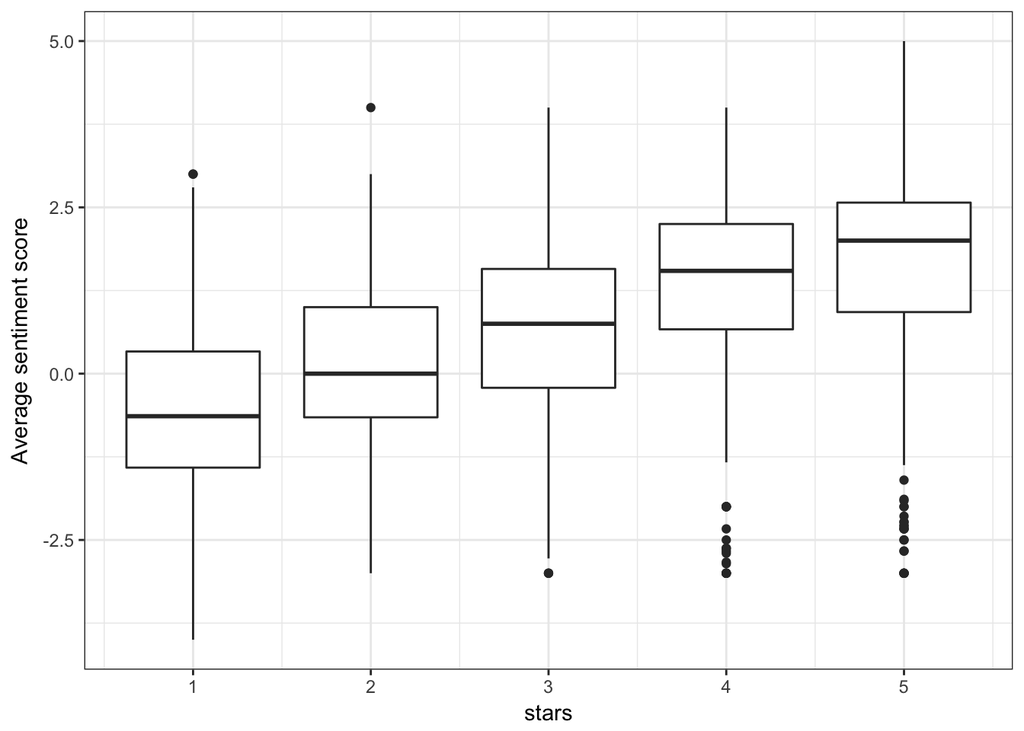

```r
theme_set(theme_bw())

ggplot(reviews_sentiment, aes(stars, sentiment, group = stars)) +
  geom_boxplot() +
  ylab("Average sentiment score")
```

Question: What does that plot show about the relationship between sentiment and star rating?

# Word and Document Frequency

- How can we quantify what a document is about?
- Count the frequency of terms that make up a document.
- Words such as “the”, “is”, etc. can occur frequently.
- Could use stop words, but this approach is limited, especially for commonly used words.

## Term Frequency

The term frequency in a document is number of times a term $\text t$ occurs in document $\text d$,

$$\text{tf}_\text{t,d}.$$

## Inverse Document Frequency

- The inverse document frequency (IDF) is a statistical weight used for measuring the importance of a term in a text document collection. The document frequency DF of a term is defined by the number of documents in which a term appears.
- Karen Sparck-Jones first proposed that terms with low document frequency are more valuable than terms with high document frequency during retrieval (Sparck-Jones K., 1972.).
- In other words, the underlying idea of IDF is that the more frequently the term appears in the collection, the less informative the term is.

The *inverse document frequency* of a term $\text t$ is,

$$\text{idf}_\text{t}=\log\left(\frac{N}{\text{df}_\text{t}}\right).$$

$N$ is the total number of documents in a collection (or corpus) of documents, and $\text{df}_\text{t}$ is the number of documents in a collection that contain the term $\text t$.

## Tf-idf Weighting

A weight for each term in each document is given by multiplying term frequency and inverse document frequency.

$$\text{tf-idf}_\text{t,d}= \text{tf}_\text{t,d} \times \log\left(\frac{N}{\text{df}_\text{t}}\right).$$

Some properties of Tf-idf [(see Manning et al.)](https://nlp.stanford.edu/IR-book/html/htmledition/tf-idf-weighting-1.html):

1. highest when $t$ occurs many times within a small number of documents (thus lending high discriminating power to those documents);
2. lower when the term occurs fewer times in a document, or occurs in many documents (thus offering a less pronounced relevance signal);
3. lowest when the term occurs in virtually all documents.

# Jane Austen’s novels

```r
book_words <- austen_books() %>%
  unnest_tokens(word, text) %>%
  count(book, word, sort = TRUE) %>%
  ungroup()

total_words <- book_words %>%
  group_by(book) %>%
  summarize(total = sum(n))

book_words <- left_join(book_words, total_words)

book_words
```

```
## # A tibble: 40,379 x 4
##    book              word      n  total
##    <fct>             <chr> <int>  <int>
##  1 Mansfield Park    the    6206 160460
##  2 Mansfield Park    to     5475 160460
##  3 Mansfield Park    and    5438 160460
##  4 Emma              to     5239 160996
##  5 Emma              the    5201 160996
##  6 Emma              and    4896 160996
##  7 Mansfield Park    of     4778 160460
##  8 Pride & Prejudice the    4331 122204
##  9 Emma              of     4291 160996
## 10 Pride & Prejudice to     4162 122204
## # ... with 40,369 more rows
```

- One row for each word-book combination.

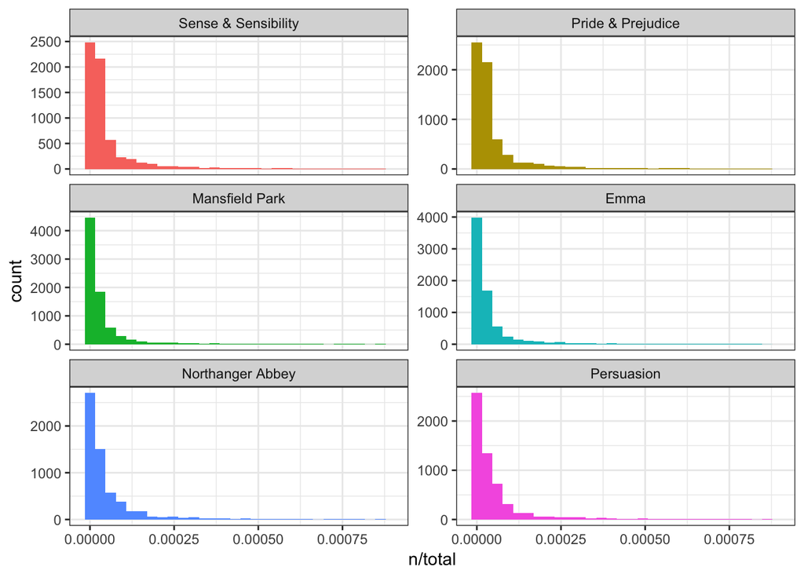

```r
ggplot(book_words, aes(n/total, fill = book)) +
  geom_histogram(show.legend = FALSE) +
  xlim(NA, 0.0009) +
  facet_wrap(~book, ncol = 2, scales = "free_y")
```

We can calculate tf-idf for the Jane Austen novels.

```r
book_words <- book_words %>% bind_tf_idf(word, book, n)
book_words
```

```
## # A tibble: 40,379 x 7
##    book              word      n  total     tf   idf tf_idf
##    <fct>             <chr> <int>  <int>  <dbl> <dbl>  <dbl>
##  1 Mansfield Park    the    6206 160460 0.0387     0      0
##  2 Mansfield Park    to     5475 160460 0.0341     0      0
##  3 Mansfield Park    and    5438 160460 0.0339     0      0
##  4 Emma              to     5239 160996 0.0325     0      0
##  5 Emma              the    5201 160996 0.0323     0      0
##  6 Emma              and    4896 160996 0.0304     0      0
##  7 Mansfield Park    of     4778 160460 0.0298     0      0
##  8 Pride & Prejudice the    4331 122204 0.0354     0      0
##  9 Emma              of     4291 160996 0.0267     0      0
## 10 Pride & Prejudice to     4162 122204 0.0341     0      0
## # ... with 40,369 more rows
```

Let’s look at terms with high tf-idf in Jane Austen’s works.

```r
book_words %>%
  dplyr::select(-total) %>%
  arrange(desc(tf_idf))
```

```
## # A tibble: 40,379 x 6
##    book                word          n      tf   idf  tf_idf
##    <fct>               <chr>     <int>   <dbl> <dbl>   <dbl>
##  1 Sense & Sensibility elinor      623 0.00519  1.79 0.00931
##  2 Sense & Sensibility marianne    492 0.00410  1.79 0.00735
##  3 Mansfield Park      crawford    493 0.00307  1.79 0.00551
##  4 Pride & Prejudice   darcy       373 0.00305  1.79 0.00547
##  5 Persuasion          elliot      254 0.00304  1.79 0.00544
##  6 Emma                emma        786 0.00488  1.10 0.00536
##  7 Northanger Abbey    tilney      196 0.00252  1.79 0.00452
##  8 Emma                weston      389 0.00242  1.79 0.00433
##  9 Pride & Prejudice   bennet      294 0.00241  1.79 0.00431
## 10 Persuasion          wentworth   191 0.00228  1.79 0.00409
## # ... with 40,369 more rows
```

# Supervised Learning

## Success of lawyer

- In 2014 the Law Society of Upper Canada charged a Toronto refugee lawyer for failing to represent his clients.
- Part of the evidence involved evaluating the number of cases where his clients (people with refugees claims) were granted refugee status.
- This lawyer’s success rates were compared to several other lawyers.
- Part of the data is shown in the table below. The lawyer in question is B.

| Lawyer | Abandoned | Negative | Positive | Total |
| --- | --- | --- | --- | --- |
| A | 403 | 95 | 6 | 504 |
| B | 223 | 137 | 26 | 386 |
| C | 149 | 73 | 27 | 249 |
| **Total** | 775 | 305 | 59 | 1139 |

Conditional probability is a fundemental concept in machine learning.

## Words appearing in topics

Three scientific articles contains a number of topics including “Genetics” and “Disease”. The number of words in each article that are related to the two topics are shown in the table below.

| Document | Genetics | Disease | Total |
| --- | --- | --- | --- |
| Article 1 | 30 | 10 | 40 |
| Article 2 | 20 | 20 | 40 |
| Article 3 | 15 | 5 | 20 |
| **Total** | 65 | 35 | 100 |

- This is a simple example of topic modelling.

## Examples of Classification Problems

- A person arrives at the emrgency room with a set of symptoms. The symptoms can be attributed to one of two medical conditions. Which of the two medical conditions does the individual have?
- Several works of fiction are recently discovered in an archive. Various features of the style of the document seem to indicate that the works were either written by Shakespeare or Jonson. Who authored the recently discovered documents?
- An email is sent to your address. Various features of the email can be used to classify the email as spam or not spam. Is the email spam or not spam?

## Linear Regression Analysis

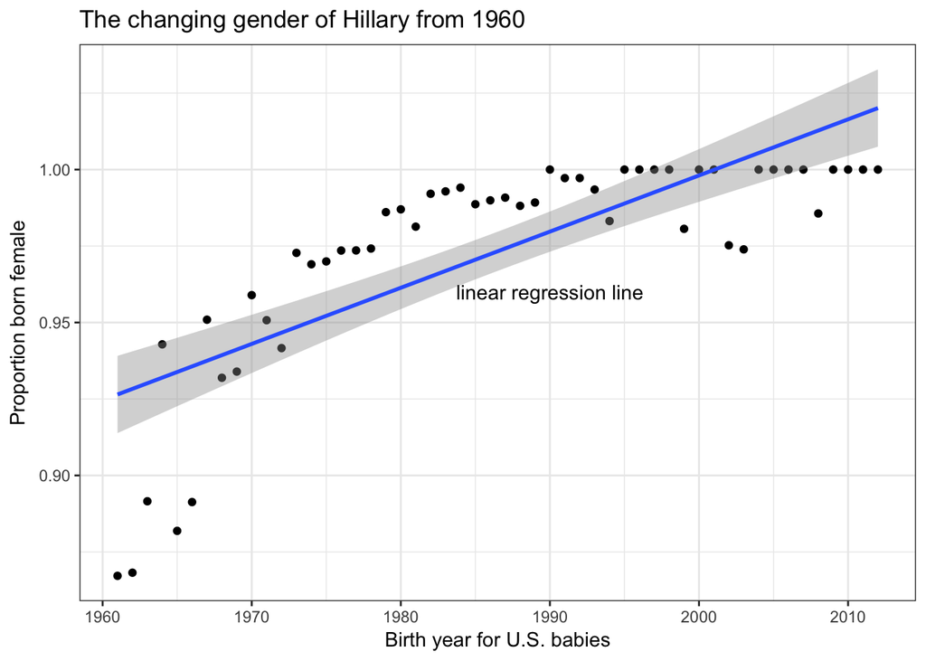

```r
gendat <- gender:::basic_names %>%
  filter(name %in% c("hillary")) %>% filter(year >1960) %>%
  mutate(proportion_female = female / (female + male))

ggplot(gendat, aes(x = year, y = proportion_female)) +
  geom_point() + geom_smooth(method = "lm",se=TRUE) +
  ggtitle("The changing gender of Hillary from 1960") +
  xlab("Birth year for U.S. babies") +
  ylab("Proportion born female")+annotate("text",x=1990,y=0.96,label="linear regression line")
```

```r
mod1 <- lm(proportion_female~year,data = gendat)
tidy(mod1)
```

```
##          term     estimate    std.error statistic      p.value
## 1 (Intercept) -2.673467402 0.4221840729 -6.332469 6.642183e-08
## 2        year  0.001835769 0.0002125205  8.638080 1.742160e-11
```

```r
predict(mod1,newdata = data.frame(year=c(2009)))
```

```
##        1
## 1.014593
```

- The problem with this model is that the dependent variable (male/female) is a proportion so it should always be between 0 and 1.
- Logistic regression is the correct type of regression model for a dependent variable that has two unordered categories.

```r
mod2 <- glm(cbind(female,male)~year,family = binomial,data=gendat)
tidy(mod2)
```

```
##          term     estimate    std.error statistic      p.value
## 1 (Intercept) -200.4628470 10.158099855 -19.73429 1.094828e-86
## 2        year    0.1032577  0.005137438  20.09907 7.518332e-90
```

```r
predict(mod2,newdata = data.frame(year=c(2009)),type = "response")
```

```
##         1
## 0.9990724
```

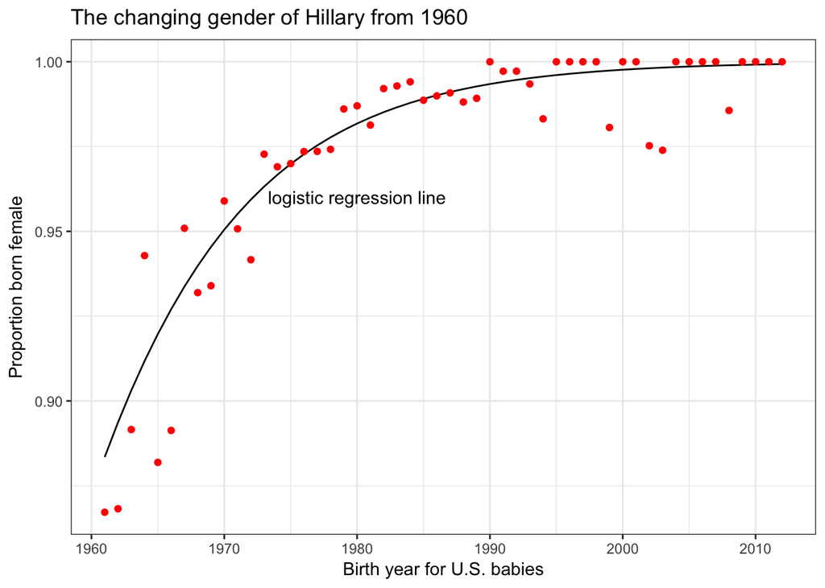

```r
ggplot(gendat,aes(x=year,y=predict(mod2,type="response")))+geom_line()+
  geom_point(data=gendat,aes(y=proportion_female),colour="red")+
  ggtitle("The changing gender of Hillary from 1960") +
  xlab("Birth year for U.S. babies") +
  ylab("Proportion born female")+
  ylab("Proportion born female")+annotate("text",x=1980,y=0.96,label="logistic regression line")
```

## Logistic Regression Analysis

- Logistic regression is similar to linear regression except that the dependent vaarieble is categorical (e.g., gender).
- Logistic regression can be used to predict which category (often called class) an observation falls into.

## Evaluating Prediction Accuracy

|  | Observed Class |  |  |
| --- | --- | --- | --- |
| **Predicted Class** | email | spam | **Total** |
| email | a | b | a+b |
| spam | c | d | c+d |
| **Total** | a+c | b+d |  |

Case Study: Supervised Machine Learning: Predicting e-mail spam using logistic regression

```r
library(ElemStatLearn)
library(rpart)
library(tree)
library(maptree)
library(ggplot2)

DATASET <- spam
head(DATASET)
```

```
##    A.1  A.2  A.3 A.4  A.5  A.6  A.7  A.8  A.9 A.10 A.11 A.12 A.13 A.14
## 1 0.00 0.64 0.64   0 0.32 0.00 0.00 0.00 0.00 0.00 0.00 0.64 0.00 0.00
## 2 0.21 0.28 0.50   0 0.14 0.28 0.21 0.07 0.00 0.94 0.21 0.79 0.65 0.21
## 3 0.06 0.00 0.71   0 1.23 0.19 0.19 0.12 0.64 0.25 0.38 0.45 0.12 0.00
## 4 0.00 0.00 0.00   0 0.63 0.00 0.31 0.63 0.31 0.63 0.31 0.31 0.31 0.00
## 5 0.00 0.00 0.00   0 0.63 0.00 0.31 0.63 0.31 0.63 0.31 0.31 0.31 0.00
## 6 0.00 0.00 0.00   0 1.85 0.00 0.00 1.85 0.00 0.00 0.00 0.00 0.00 0.00
##   A.15 A.16 A.17 A.18 A.19 A.20 A.21 A.22 A.23 A.24 A.25 A.26 A.27 A.28
## 1 0.00 0.32 0.00 1.29 1.93 0.00 0.96    0 0.00 0.00    0    0    0    0
## 2 0.14 0.14 0.07 0.28 3.47 0.00 1.59    0 0.43 0.43    0    0    0    0
## 3 1.75 0.06 0.06 1.03 1.36 0.32 0.51    0 1.16 0.06    0    0    0    0
## 4 0.00 0.31 0.00 0.00 3.18 0.00 0.31    0 0.00 0.00    0    0    0    0
## 5 0.00 0.31 0.00 0.00 3.18 0.00 0.31    0 0.00 0.00    0    0    0    0
## 6 0.00 0.00 0.00 0.00 0.00 0.00 0.00    0 0.00 0.00    0    0    0    0
##   A.29 A.30 A.31 A.32 A.33 A.34 A.35 A.36 A.37 A.38 A.39 A.40 A.41 A.42
```

[output cut: 20 more lines]

```r
dim(DATASET)
```

```
## [1] 4601   58
```

```r
nrow(DATASET)
```

```
## [1] 4601
```

```r
ncol(DATASET)
```

```
## [1] 58
```

```r
colnames(DATASET)
```

```
##  [1] "A.1"  "A.2"  "A.3"  "A.4"  "A.5"  "A.6"  "A.7"  "A.8"  "A.9"  "A.10"
## [11] "A.11" "A.12" "A.13" "A.14" "A.15" "A.16" "A.17" "A.18" "A.19" "A.20"
## [21] "A.21" "A.22" "A.23" "A.24" "A.25" "A.26" "A.27" "A.28" "A.29" "A.30"
## [31] "A.31" "A.32" "A.33" "A.34" "A.35" "A.36" "A.37" "A.38" "A.39" "A.40"
## [41] "A.41" "A.42" "A.43" "A.44" "A.45" "A.46" "A.47" "A.48" "A.49" "A.50"
## [51] "A.51" "A.52" "A.53" "A.54" "A.55" "A.56" "A.57" "spam"
```

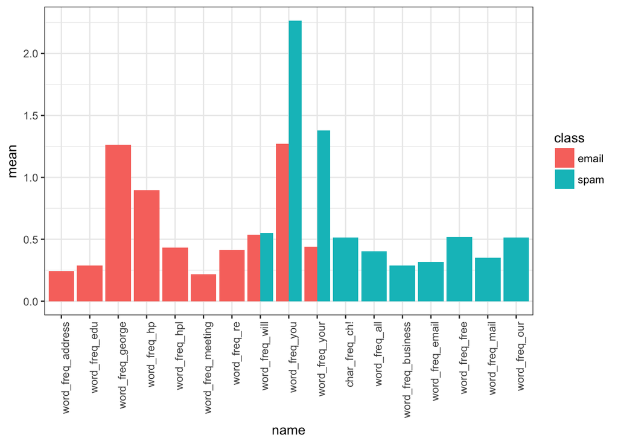

```r
# Change Column Names

newColNames <- c("word_freq_make", "word_freq_address", "word_freq_all", "word_freq_3d",
    "word_freq_our", "word_freq_over", "word_freq_remove", "word_freq_internet",
    "word_freq_order", "word_freq_mail", "word_freq_receive", "word_freq_will",
    "word_freq_people", "word_freq_report", "word_freq_addresses", "word_freq_free",
    "word_freq_business", "word_freq_email", "word_freq_you", "word_freq_credit",
    "word_freq_your", "word_freq_font", "word_freq_000", "word_freq_money",
    "word_freq_hp", "word_freq_hpl", "word_freq_george", "word_freq_650", "word_freq_lab",
    "word_freq_labs", "word_freq_telnet", "word_freq_857", "word_freq_data",
    "word_freq_415", "word_freq_85", "word_freq_technology", "word_freq_1999",
    "word_freq_parts", "word_freq_pm", "word_freq_direct", "word_freq_cs", "word_freq_meeting",
    "word_freq_original", "word_freq_project", "word_freq_re", "word_freq_edu",
    "word_freq_table", "word_freq_conference", "char_freq_ch;", "char_freq_ch(",
    "char_freq_ch[", "char_freq_ch!", "char_freq_ch$", "char_freq_ch#", "capital_run_length_average",
    "capital_run_length_longest", "capital_run_length_total", "spam")

colnames(DATASET) <- newColNames

dataset.email <- sapply(DATASET[which(DATASET$spam == "email"),1:54],mean)
dataset.spam <- sapply(DATASET[which(DATASET$spam == "spam"),1:54],mean)

dataset.email.order <- data.frame(name=names(dataset.email[order(-dataset.email)[1:10]]),
                                  mean=dataset.email[order(-dataset.email)[1:10]],class=rep("email",10))
dataset.spam.order <- data.frame(name=names(dataset.spam[order(-dataset.spam)[1:10]]),
                                            mean=dataset.spam[order(-dataset.spam)[1:10]],class=rep("spam",10))

dataset.plot <-rbind(dataset.email.order,dataset.spam.order)

ggplot(dataset.plot,aes(x=name, y=mean,fill=class))+
  geom_bar(stat="identity",position="dodge")+
  theme(axis.text.x=element_text(angle=90,hjust=1))
```

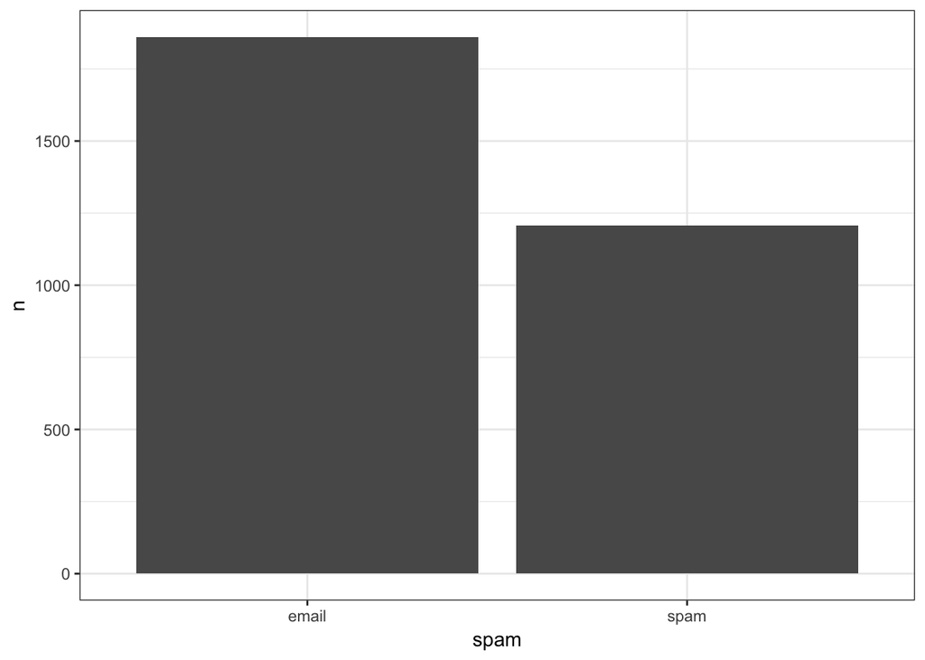

```r
# training and test sets

set.seed(1423)
index <- 1:nrow(DATASET)
trainIndex <- sample(index, trunc(length(index) * 0.666666666666667))
DATASET.train <- DATASET[trainIndex, ]

DATASET.train %>% group_by(spam) %>% summarise(n=n()) %>% ggplot(aes(x=spam,y=n))+geom_bar(stat="identity")
```

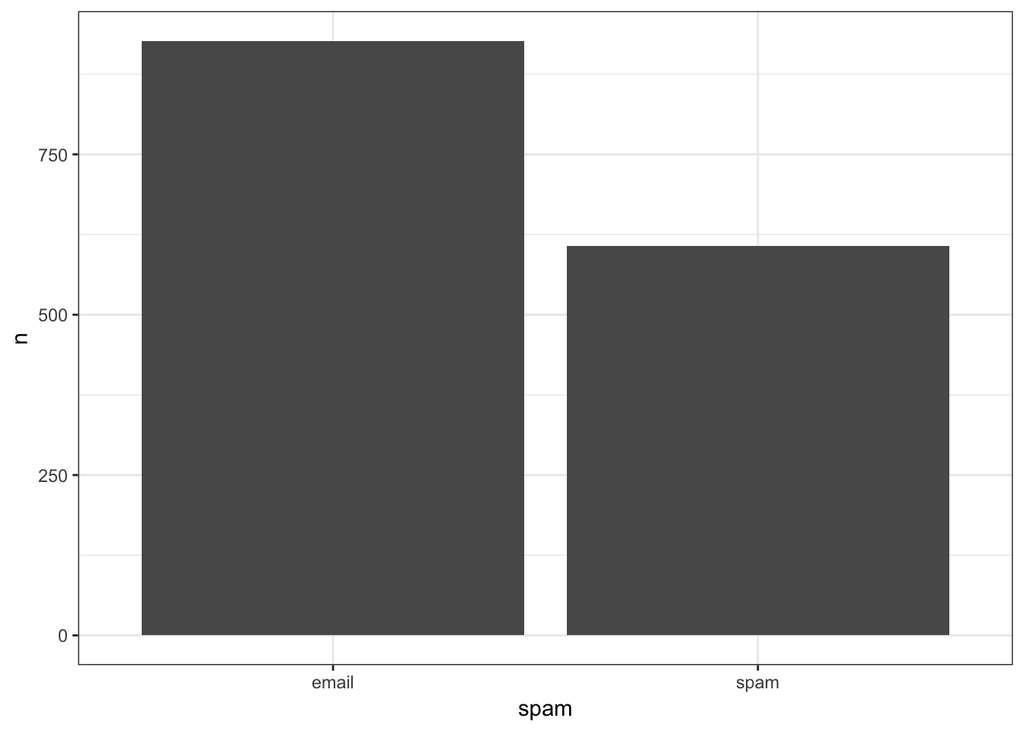

```r
DATASET.test <- DATASET[-trainIndex, ]

DATASET.test %>% group_by(spam) %>% summarise(n=n()) %>% ggplot(aes(x=spam,y=n))+geom_bar(stat="identity")
```

```r
# logistic regression tree

contrasts(DATASET.train$spam)
```

```
##       spam
## email    0
## spam     1
```

```r
# model P(spam=1|features)

model.logreg <- glm(spam ~ .,family = binomial ,data = DATASET.train)

# use model to predict test data

predcit.test.lr <- predict(model.logreg,newdata = DATASET.test,type="response")

predict.email <- if_else(predcit.test.lr>=0.5,"spam","email")

# confusion matrix
table(predict.email,DATASET.test$spam)
```

```
##
## predict.email email spam
##         email   880   71
##         spam     47  536
```

```r
#overall accuracy

1-sum(DATASET.test$spam != predict.email)/nrow(DATASET.test)
```

```
## [1] 0.9230769
```